List of Packages used; - caret - corrplot - dplyr - missForest

```r
library(caret)
```

```r
library(corrplot)
library(dplyr)
library(missForest) # will be used to impute missing values
# browse to the data
moneyball = read.csv('/Users/legs_jorge/Documents/Data Science Projects/MSDS_Northwestern/MSDS 411/Unit 01 Moneyball Baseball Problem/Data/moneyball.csv', header = T)
```

Let’s do a quick analysis to understand the distribution Null values accross our dataset. Here, we count the number of NAs and divide it by the number of rows to get a per columns percentage of NAs.

```r
#let check for NAs in the data
#Counting the number of NAs per column and check the percentage of NAs per column
NAPerc <- sapply(moneyball, function(x) (sum(is.na(x))/length(x))*100) %>%
  data.frame()
NAPerc$Column <- rownames(NAPerc)
colnames(NAPerc) <- c("NA_Perc", "Col_Name")
NAPerc
```

```
##                    NA_Perc         Col_Name
## INDEX             0.000000            INDEX
## TARGET_WINS       0.000000      TARGET_WINS
## TEAM_BATTING_H    0.000000   TEAM_BATTING_H
## TEAM_BATTING_2B   0.000000  TEAM_BATTING_2B
## TEAM_BATTING_3B   0.000000  TEAM_BATTING_3B
## TEAM_BATTING_HR   0.000000  TEAM_BATTING_HR
## TEAM_BATTING_BB   0.000000  TEAM_BATTING_BB
## TEAM_BATTING_SO   4.481547  TEAM_BATTING_SO
## TEAM_BASERUN_SB   5.755712  TEAM_BASERUN_SB
## TEAM_BASERUN_CS  33.919156  TEAM_BASERUN_CS
## TEAM_BATTING_HBP 91.608084 TEAM_BATTING_HBP
## TEAM_PITCHING_H   0.000000  TEAM_PITCHING_H
## TEAM_PITCHING_HR  0.000000 TEAM_PITCHING_HR
## TEAM_PITCHING_BB  0.000000 TEAM_PITCHING_BB
## TEAM_PITCHING_SO  4.481547 TEAM_PITCHING_SO
## TEAM_FIELDING_E   0.000000  TEAM_FIELDING_E
## TEAM_FIELDING_DP 12.565905 TEAM_FIELDING_DP
```

Let’s focus only on columns with missing values.

```r
subset(NAPerc,NA_Perc > 0) %>% arrange(desc(NA_Perc))
```

```
##     NA_Perc         Col_Name
## 1 91.608084 TEAM_BATTING_HBP
## 2 33.919156  TEAM_BASERUN_CS
## 3 12.565905 TEAM_FIELDING_DP
## 4  5.755712  TEAM_BASERUN_SB
## 5  4.481547  TEAM_BATTING_SO
## 6  4.481547 TEAM_PITCHING_SO
```

Looks like we will be deleting the TEAM_BATTING_HPB, But first I need to understand why it’s missing. After doing some reading it looks like that columns could be translated to a 0 or 1. I need to do more investigating. From working experience, usually columns with high volumes of NAs indicates important informations, simply because they could be capturing rare instance where a process fails. Instead of deleting it, I will try to see if I can transform it into a categorical variable with 1s and 0s. Now, regarding the other one, I will try some other inputation methods such as KNN, mean, median, etc. [Here](https://www.r-bloggers.com/imputing-missing-data-with-r-mice-package/) is a great article from Rblogger that discusses the package [MICE](https://cran.r-project.org/web/packages/mice/mice.pdf).

### Let the Inputation begin

Before we start the imputation, let’s try to understand why we have missing data.

**There are two types of missing data** - MCAR: missing completely at random. This is the desirable scenario in case of missing data. - MNAR: missing not at random. Missing not at random data is a more serious issue and in this case it might be wise to check the data gathering process further and try to understand why the information is missing. For instance, if most of the people in a survey did not answer a certain question, why did they do that? Was the question unclear?

It would be good to understand exactly what type of missing value we are dealing with.

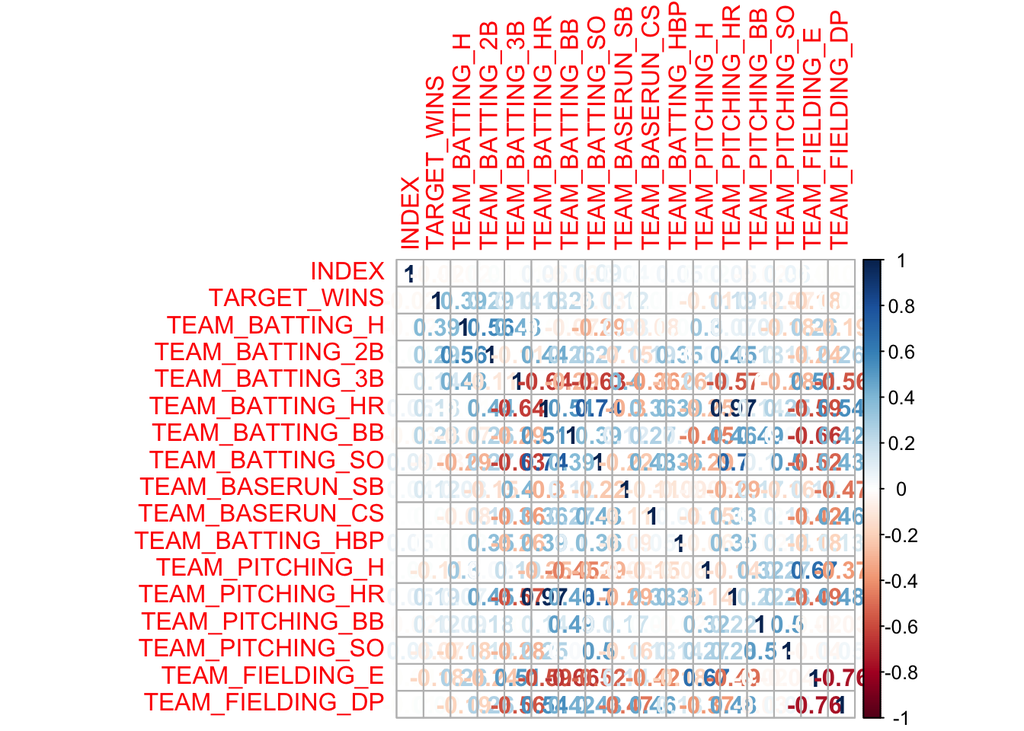

```r
moneyball[is.na(moneyball) == TRUE] <- 0
mball_cor <- cor(moneyball)
corrplot(mball_cor, method="number")
```

```r
findCorrelation(mball_cor, .75)
```

```
## [1]  6 16
```

```r
findLinearCombos(mball_cor)
```

```
## $linearCombos
## list()
##
## $remove
## NULL
```